# Between Hopes and Fears, Burkina Faso faces the modernization of its CRVS system: *Based on the discussions of the 2019 national consultation on CRVS in Burkina Faso*

Ramoudane Orou Sannou

12/12/2019

## 1. Introduction

Burkina Faso is currently facing instability due to terrorist attacks in some regions that are causing massive population displacements within the country. As a result, civil registration and the production of vital statistics in Burkina Faso is now at the center of social debates and occupies the attention of decision-makers. The existence of an effective civil registration system will prevent issues related to statelessness, loss of property, identity theft, etc., that may arise as a result of the ongoing instability in some parts of the country. Better still, the regular production of vital statistics could serve as a powerful tool for monitoring the country’s demographic indicators, avoiding the organization of costly population censuses, and ultimately providing policy makers with evidence that can be used to formulate clear policies that are adapted to the real needs of the population.

Among other activities, UNFPA is supporting civil registration actors in Burkina Faso to modernize the CRVS system in the country. To this end, UNFPA Burkina Faso Country Office supported the government’s efforts to reform the system which led to the creation of a Framework for Civil Registration Actors (Cadre Partenarial des Acteurs de l’état civil - CAPEC) that brings together all stakeholders involved in the registration of vital events and the production of vital statistics *(Figure 1)*. In addition, through a partnership with the Demographic Surveillance Systems (HDSS) in Kaya, Nanoro and Nouna UNFPA is conducting a study that aims to assess the completeness of civil registration data and to unravel the proximate determinants of under-registration of vital events in these three regions.

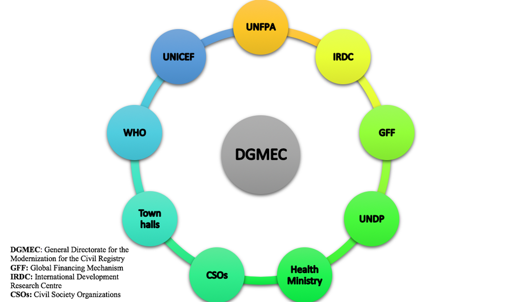

**Figure 1: Partnership Framework for Civil Registration Actors**

## 2. iCivil, an innovative solution for birth registration in Burkina Faso

Burkina Faso has resolutely turned towards the modernization of its civil registration system through the use of ICTs, with a focus on birth registration. After conducting an assessment of the modern civil registration systems already in use in the country, the government decided to select iCivil as the standard system to be rolled-out throughout its territory. iCivil is an impressive technological solution co-invented by a Burkina Faso national that automatically generates digital registers of vital events. In its current version, iCivil has a mobile application for birth registration that uses encrypted SMS messages. The information on each newborn is sent by SMS from the iCivil smartphone of the duly authorized health professional, after coupling to a unique and forgery-proof identifier/authentifier called ‘’Bubble Tag’’ *(Figure 2)*. The SMS is received instantly on the server of the national civil registry authority. The SMS/Bubble Tag couple automatically fills in a birth form that will be ready to be printed and signed by the competent authority (iCivil, 2019).

[figure not shown]

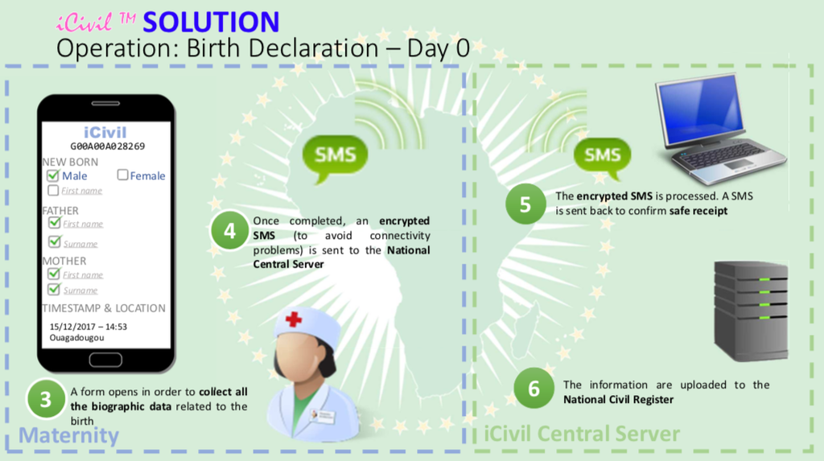

*Source: iCivil, 2019*

**Figure 2: Illustration of how iCivil works**

## 3. Between hopes and fears

iCivil has been recognized as the most appropriate solution for under-registration of births and - by extension - of other vital events in Burkina Faso. This technology has many advantages such as the celerity in processing birth certificates, the digitalization of all information on births and thus reduction of the risk of loss, the centralization of all birth data that facilitates the production of statistics. However, civil registration is not limited to births and is a social act that can be influenced by several factors. Indeed, modernizing the system is a major step towards streamlining civil registration process, especially for the most disadvantaged groups. However, for vital events such as marriages, deaths and even births to some extent, there may be socio-economic and cultural factors that constitute barriers to their registration. In light of the many hopes that the prospect of the deployment of iCivil brings, CAPEC recognizes the importance of considering the socio-economic and contextual factors that could hinder the deployment of this technology. During the national consultation held from 28 to 29 November 2019, concerns were expressed pertaining to the deployment of iCivil by 30 different stakeholders. We have grouped these fears into two main categories *(Figure 3)*.

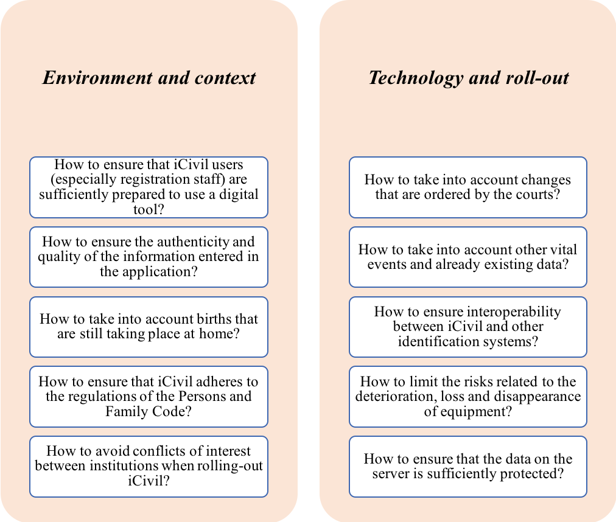

**Figure 3: Summary of CAPEC’s concerns**

## 4. Conclusion

- The reaffirmation of MATDC’s exclusive leadership on the issue of civil registration in Burkina Faso,
- The revision of the National Strategy on Civil Registration and the Persons and Family Code (already in progress) in order to adopt digital tools for civil registration and factor in all the above-mentioned concerns and solutions,
- The rapid deployment of iCivil throughout Burkina Faso and,
- Taking into account the urgent and special nature of IDPs and refugees in Burkina Faso.